← Back to Project Report

# Data Preprocessing and EDA for E‑Commerce Orders

Objective of this section will be to:

- Load **four tables** (`orders`, `order_items`, `order_shipping`, `payments`).
- Join them into a single order-level dataset.
- Clean and transform the data.
- Perform basic EDA and visualization.

This report outlines the end-to-end pipeline for consolidating fragmented e-commerce tables to analyze order behavior and logistics performance.

## Setup

Run the cell below to import the required Python packages.

```python
import numpy as np
import pandas as pd
import matplotlib.pyplot as plt
import sklearn
import seaborn as sns

plt.style.use('seaborn-v0_8')
```

## Part 1: Data Preprocessing

### Data Loading & Joining

We first load each table, inspect it, and then join them into a single DataFrame.

#### Load the CSV files

In this initial phase, the data foundation is established by ingesting the raw relational datasets. Specifically df_orders, df_order_items, df_shipping, and df_payments. This step ensures that all core entities are correctly mapped into the environment before moving to the integration and transformation stages.

```python
# Load the CSV files
df_order_items = pd.read_csv('order_items.csv')
df_shipping = pd.read_csv('order_shipping.csv')
df_orders = pd.read_csv('orders.csv')
df_payments = pd.read_csv('payments.csv')
```

#### Inspect each table

By examining the initial records and dimensional shapes, the underlying relational schema is validated, ensuring a clear understanding of the data grain before proceeding to integration.

```python
# Execute structural audit for all primary dataframes
display(df_order_items.head())
print(f"Shape of order_items: {df_order_items.shape}")

display(df_shipping.head())
print(f"Shape of order_shipping: {df_shipping.shape}")

display(df_orders.head())
print(f"Shape of orders: {df_orders.shape}")

display(df_payments.head())
print(f"Shape of payments: {df_payments.shape}")
```

|  | order_id | num_items | num_unique_products | num_unique_sellers | total_item_price | avg_item_price | total_freight_value | top_product_category |
| --- | --- | --- | --- | --- | --- | --- | --- | --- |
| 0 | sdv-id-whzjUX | 1 | 1 | 1 | 352.420029 | 369.966521 | 68.790159 | construction_tools_construction |
| 1 | sdv-id-gqShVM | 1 | 1 | 1 | 1580.187928 | 1089.284136 | 84.603289 | auto |
| 2 | sdv-id-vtaqcY | 1 | 1 | 1 | 45.969263 | 36.969754 | 24.022637 | furniture_decor |
| 3 | sdv-id-xkqwdo | 1 | 1 | 1 | 146.023435 | 126.755360 | 16.945349 | consoles_games |
| 4 | sdv-id-sGyHvQ | 1 | 1 | 1 | 30.525812 | 22.797409 | 17.785846 | air_conditioning |

```
Shape of order_items: (100000, 8)
```

|  | order_id | customer_state |
| --- | --- | --- |
| 0 | sdv-id-whzjUX | Massachusetts |
| 1 | sdv-id-gqShVM | Ohio |
| 2 | sdv-id-vtaqcY | Wisconsin |
| 3 | sdv-id-xkqwdo | Michigan |
| 4 | sdv-id-sGyHvQ | Nevada |

```
Shape of order_shipping: (100000, 2)
```

|  | order_id | order_status | order_purchase_hour | order_purchase_dayofweek | order_purchase_month | order_total_value |
| --- | --- | --- | --- | --- | --- | --- |
| 0 | sdv-id-whzjUX | shipped | 10 | 4 | 4 | 744.312535 |
| 1 | sdv-id-gqShVM | delivered | 19 | 2 | 4 | 1030.521912 |
| 2 | sdv-id-vtaqcY | delivered | 18 | 4 | 8 | 28.472994 |
| 3 | sdv-id-xkqwdo | invoiced | 23 | 1 | 8 | 143.914263 |
| 4 | sdv-id-sGyHvQ | delivered | 19 | 0 | 2 | 16.944537 |

```
Shape of orders: (100000, 6)
```

|  | order_id | payment_type |
| --- | --- | --- |
| 0 | sdv-id-whzjUX | voucher |
| 1 | sdv-id-gqShVM | voucher |
| 2 | sdv-id-vtaqcY | voucher |
| 3 | sdv-id-xkqwdo | credit_card |
| 4 | sdv-id-sGyHvQ | credit_card |

```
Shape of payments: (100000, 2)
```

#### Join the tables on `order_id` to create a single order-level DataFrame

A unified "Order Analytical Record" (df_orders_full) is constructed by executing a series of inner joins on the order_id primary key. This systematic integration of df_orders, df_order_items, df_shipping, and df_payments ensures that the final dataset contains only synchronized records present across all functional domains, providing a consistent foundation for downstream analysis.

```python
# Consolidate core order metadata with itemized transaction data
step1 = pd.merge(df_orders, df_order_items, on='order_id', how='inner')

# Enrich integrated records with logistics/shipping dimensions
step2 = pd.merge(step1, df_shipping, on='order_id', how='inner')

# Finalize the master analytical record with payment data
df_orders_full = pd.merge(step2, df_payments, on='order_id', how='inner')

# Validation of the integrated master dataset
display(df_orders_full.head())
print(f"Final result dataframe shape: {df_orders_full.shape}")
```

|  | order_id | order_status | order_purchase_hour | order_purchase_dayofweek | order_purchase_month | order_total_value | num_items | num_unique_products | num_unique_sellers | total_item_price | avg_item_price | total_freight_value | top_product_category | customer_state | payment_type |
| --- | --- | --- | --- | --- | --- | --- | --- | --- | --- | --- | --- | --- | --- | --- | --- |
| 0 | sdv-id-whzjUX | shipped | 10 | 4 | 4 | 744.312535 | 1 | 1 | 1 | 352.420029 | 369.966521 | 68.790159 | construction_tools_construction | Massachusetts | voucher |
| 1 | sdv-id-gqShVM | delivered | 19 | 2 | 4 | 1030.521912 | 1 | 1 | 1 | 1580.187928 | 1089.284136 | 84.603289 | auto | Ohio | voucher |
| 2 | sdv-id-vtaqcY | delivered | 18 | 4 | 8 | 28.472994 | 1 | 1 | 1 | 45.969263 | 36.969754 | 24.022637 | furniture_decor | Wisconsin | voucher |
| 3 | sdv-id-xkqwdo | invoiced | 23 | 1 | 8 | 143.914263 | 1 | 1 | 1 | 146.023435 | 126.755360 | 16.945349 | consoles_games | Michigan | credit_card |
| 4 | sdv-id-sGyHvQ | delivered | 19 | 0 | 2 | 16.944537 | 1 | 1 | 1 | 30.525812 | 22.797409 | 17.785846 | air_conditioning | Nevada | credit_card |

```
Final result dataframe shape: (100000, 15)
```

### Data Cleaning

#### Handle missing values

```python
# Handle missing values

for col in df_orders_full.columns:
  if df_orders_full[col].dtype in ['float64','int64']:
    median_val = df_orders_full[col].median()
    df_orders_full[col] = df_orders_full[col].fillna(median_val)

  elif df_orders_full[col].dtype == 'object':
    mode_val = df_orders_full[col].mode()[0]
    df_orders_full[col] = df_orders_full[col].fillna(mode_val)

# Enforce record-level integrity by removing rows with missing primary identifiers
df_orders_full.dropna(subset=['order_id','payment_type'], inplace=True)

# Validation of cleaned data state
print(f"Dataframe df_orders_full shape: {df_orders_full.shape}")
```

```
Dataframe df_orders_full shape: (99678, 15)
```

#### Remove clearly invalid numeric records

The dataset is refined by removing records that violate fundamental business logic or physical constraints. A validation layer is applied to ensure that all transactional quantities and monetary values (specifically num_items, order_total_value, total_item_price, and total_freight_value) align with real-world operational standards. This step is critical for maintaining the integrity of downstream financial modeling and statistical distributions.

```python
# Filter invalid numeric records

df_orders_full = df_orders_full[
    (df_orders_full['num_items'] > 0) &
    (df_orders_full['order_total_value'] > 0) &
    (df_orders_full['total_item_price'] >= 0) &
    (df_orders_full['total_freight_value'] >= 0)
]

# Quantify the impact of the filtering process
print(f"Dataframe df_orders_full shape: {df_orders_full.shape}")
```

```
Dataframe df_orders_full shape: (88853, 15)
```

#### Check cleanliness and key uniqueness

```python
# Ensure zero missingness across all features
null_counts = df_orders_full.isnull().sum().sum()

if null_counts == 0:
  print("There are no null values in dataset")
else:
  print("There are some null values existing in dataset")
  print(null_counts[null_counts>0])

# Validate the primary key at the order grain
total_rows = df_orders_full.shape[0]
unique_orders = df_orders_full['order_id'].nunique()

if total_rows == unique_orders:
  print("Rows are unique")
else:
  print(f"There are {total_rows - unique_orders} duplicated rows")
```

```
There are some null values existing in dataset
[866]
Rows are unique
```

### Data Transformation

Advanced sanity checks are applied to the df_orders_full dataset to ensure internal consistency between interrelated metrics. By enforcing strict logical constraints the data integrity is solidified for downstream feature engineering.

#### Sanity checks on counts and values

1. The total item count must logically be greater than or equal to the count of unique products
2. The total order value must encompass the combined sum of item prices and freight charges

```python
# Apply logical consistency constraints to ensure transactional integrity

df_orders_full = df_orders_full[
    (df_orders_full['num_items'] >= df_orders_full['num_unique_products']) &
    (df_orders_full['order_total_value'] >= df_orders_full['total_item_price'] + df_orders_full['total_freight_value'])
]

# Audit the dataset following the application of logical constraints
print(f"Dataframe df_orders_full shape: {df_orders_full.shape}")
```

```
Dataframe df_orders_full shape: (46076, 15)
```

#### Create `order_value_per_item`

By calculating the order_value_per_item, a normalized unit-value feature is established. This metric is essential for identifying high-margin transactions and segmenting consumer purchasing behavior based on average item cost rather than gross transaction totals.

```python
# order_value_per_item: Captures the average economic value of each unit within a basket

df_orders_full['order_value_per_item'] = df_orders_full['total_item_price'] / df_orders_full['num_items']

# Validate the addition of the new feature dimension
print(f"Dataframe df_orders_full shape: {df_orders_full.shape}")
```

```
Dataframe df_orders_full shape: (46076, 16)
```

#### Create `order_size_category`

Segmentation logic is applied to categorize transactions based on their physical volume. By defining the order_size_category attribute, the continuous num_items variable is transformed into discrete classes (Small, Medium, and Large). This categorization facilitates high-level comparative analysis, allowing for the identification of distinct purchasing patterns and logistics requirements across different order scales.

```python
# Small: 1-2 items | Medium: 3-5 items | Large: >5 items

conditions = [
    (df_orders_full['num_items'] <= 2),
    (df_orders_full['num_items'] <= 5),
    (df_orders_full['num_items'] > 2)
]

choices = ['Small','Medium','Large']

df_orders_full['order_size_category'] = np.select(conditions, choices, default='unknown')
```

#### Final transformation check

```python
# Ensure feature engineering did not introduce missingness
print(df_orders_full.isnull().sum())

# Inspect data types and memory usage
df_orders_full.info()

# Capture the terminal shape of the workflow
print(f"Final Shape of Dataframe df_orders_full {df_orders_full.shape}")

# Review the enriched record structure
display(df_orders_full.head())
```

```
order_id                      0
order_status                  0
order_purchase_hour           0
order_purchase_dayofweek      0
order_purchase_month          0
order_total_value             0
num_items                     0
num_unique_products           0
num_unique_sellers            0
total_item_price              0
avg_item_price                0
total_freight_value           0
top_product_category        523
customer_state                0
payment_type                  0
order_value_per_item          0
order_size_category           0
dtype: int64
<class 'pandas.DataFrame'>
Index: 46076 entries, 0 to 99997
Data columns (total 17 columns):
 #   Column                    Non-Null Count  Dtype
---  ------                    --------------  -----
 0   order_id                  46076 non-null  str
 1   order_status              46076 non-null  str
 2   order_purchase_hour       46076 non-null  int64
 3   order_purchase_dayofweek  46076 non-null  int64
 4   order_purchase_month      46076 non-null  int64
 5   order_total_value         46076 non-null  float64
 6   num_items                 46076 non-null  int64
 7   num_unique_products       46076 non-null  int64
 8   num_unique_sellers        46076 non-null  int64
 9   total_item_price          46076 non-null  float64
 10  avg_item_price            46076 non-null  float64
 11  total_freight_value       46076 non-null  float64
 12  top_product_category      45553 non-null  str
 13  customer_state            46076 non-null  str
 14  payment_type              46076 non-null  str
 15  order_value_per_item      46076 non-null  float64
 16  order_size_category       46076 non-null  str
dtypes: float64(5), int64(6), str(6)
memory usage: 6.3 MB
Final Shape of Dataframe df_orders_full (46076, 17)
```

|  | order_id | order_status | order_purchase_hour | order_purchase_dayofweek | order_purchase_month | order_total_value | num_items | num_unique_products | num_unique_sellers | total_item_price | avg_item_price | total_freight_value | top_product_category | customer_state | payment_type | order_value_per_item | order_size_category |
| --- | --- | --- | --- | --- | --- | --- | --- | --- | --- | --- | --- | --- | --- | --- | --- | --- | --- |
| 0 | sdv-id-whzjUX | shipped | 10 | 4 | 4 | 744.312535 | 1 | 1 | 1 | 352.420029 | 369.966521 | 68.790159 | construction_tools_construction | Massachusetts | voucher | 352.420029 | Small |
| 5 | sdv-id-dbopoJ | delivered | 19 | 2 | 3 | 1556.667902 | 1 | 1 | 1 | 289.242639 | 1354.621410 | 15.394619 | health_beauty | Vermont | credit_card | 289.242639 | Small |
| 8 | sdv-id-FSEOvM | delivered | 15 | 4 | 8 | 62.060506 | 1 | 1 | 1 | 26.893468 | 48.485654 | 18.751282 | luggage_accessories | South Carolina | debit_card | 26.893468 | Small |
| 12 | sdv-id-bQcBUR | delivered | 21 | 0 | 8 | 73.873470 | 1 | 1 | 1 | 37.790896 | 75.704909 | 8.670875 | computers_accessories | Kentucky | credit_card | 37.790896 | Small |
| 14 | sdv-id-MPxIXB | delivered | 13 | 5 | 5 | 361.961537 | 3 | 3 | 3 | 169.528323 | 50.132979 | 34.731146 | pet_shop | Missouri | voucher | 56.509441 | Medium |

### Data Storage

The refined and validated dataset is persisted to disk. By exporting df_orders_full as a standardized flat file (ecommerce_orders_cleaned.csv), a "Single Source of Truth" is established.

#### Save cleaned dataset

```python
# Persist the high-integrity analytical dataset for downstream consumption

df_orders_full.to_csv('ecommerce_orders_cleaned.csv', index=False)
```

## Part 2: EDA & Data Visualization

We now reload the cleaned dataset and explore it. By reloading the validated ecommerce_orders_cleaned.csv into a fresh workspace, a stateless environment is established for visualization and statistical modeling. This ensures that all subsequent insights are derived from the finalized "Single Source of Truth," maintaining consistency across the reporting lifecycle.

### Load Transformed Dataset

#### Reload CSV

```python
# Load the analytical record

df_orders_cleaned = pd.read_csv('ecommerce_orders_cleaned.csv')

# Verify data availability and dimensional integrity for the EDA session
display(df_orders_cleaned.head())
print(f"Cleaned Dataframe Shape: {df_orders_cleaned.shape}")
```

|  | order_id | order_status | order_purchase_hour | order_purchase_dayofweek | order_purchase_month | order_total_value | num_items | num_unique_products | num_unique_sellers | total_item_price | avg_item_price | total_freight_value | top_product_category | customer_state | payment_type | order_value_per_item | order_size_category |
| --- | --- | --- | --- | --- | --- | --- | --- | --- | --- | --- | --- | --- | --- | --- | --- | --- | --- |
| 0 | sdv-id-whzjUX | shipped | 10 | 4 | 4 | 744.312535 | 1 | 1 | 1 | 352.420029 | 369.966521 | 68.790159 | construction_tools_construction | Massachusetts | voucher | 352.420029 | Small |
| 1 | sdv-id-dbopoJ | delivered | 19 | 2 | 3 | 1556.667902 | 1 | 1 | 1 | 289.242639 | 1354.621410 | 15.394619 | health_beauty | Vermont | credit_card | 289.242639 | Small |
| 2 | sdv-id-FSEOvM | delivered | 15 | 4 | 8 | 62.060506 | 1 | 1 | 1 | 26.893468 | 48.485654 | 18.751282 | luggage_accessories | South Carolina | debit_card | 26.893468 | Small |
| 3 | sdv-id-bQcBUR | delivered | 21 | 0 | 8 | 73.873470 | 1 | 1 | 1 | 37.790896 | 75.704909 | 8.670875 | computers_accessories | Kentucky | credit_card | 37.790896 | Small |
| 4 | sdv-id-MPxIXB | delivered | 13 | 5 | 5 | 361.961537 | 3 | 3 | 3 | 169.528323 | 50.132979 | 34.731146 | pet_shop | Missouri | voucher | 56.509441 | Medium |

```
Cleaned Dataframe Shape: (46076, 17)
```

### Unique Categories and Payment Types

A high-level census of the marketplace dimensions is conducted to quantify product diversity and financial channel preferences. By identifying the cardinality of product categories and payment methods, the operational breadth of the platform is established. The subsequent ranking of high-volume categories and dominant payment types provides critical insights into consumer demand and transaction behavior, essential for targeted marketing and payment infrastructure optimization.

```python
# Quantify categorical cardinality and primary transactional drivers
unique_categories = df_orders_cleaned['top_product_category'].nunique()
unique_payments = df_orders_cleaned['payment_type'].nunique()

print(f"Number of unique product categories: {unique_categories}")
print(f"Number of unique payment types: {unique_payments}")

# Identify the top 5 high-velocity product categories
top_categories = df_orders_cleaned['top_product_category'].value_counts().head(5)
print("--- Top 5 Product Categories ---")
print(top_categories)

# Identify the top 3 dominant payment channels
top_payments = df_orders_cleaned['payment_type'].value_counts().head(3)
print("--- Top 5 Payment Types ---")
print(top_payments)
```

```
Number of unique product categories: 71
Number of unique payment types: 5
--- Top 5 Product Categories ---
top_product_category
bed_bath_table           5895
health_beauty            4011
furniture_decor          3412
computers_accessories    3386
telephony                2570
Name: count, dtype: int64
--- Top 5 Payment Types ---
payment_type
credit_card    27776
voucher        13812
points          2532
Name: count, dtype: int64
```

### Bar Chart: Orders by Product Category

The transactional volume is visualized across the diverse product landscape to identify primary market drivers. By executing a ranked frequency analysis of the top_product_category attribute, a comprehensive demand profile is established. This visualization is essential for inventory prioritization and understanding which vertical segments contribute most significantly to the platform's order throughput.

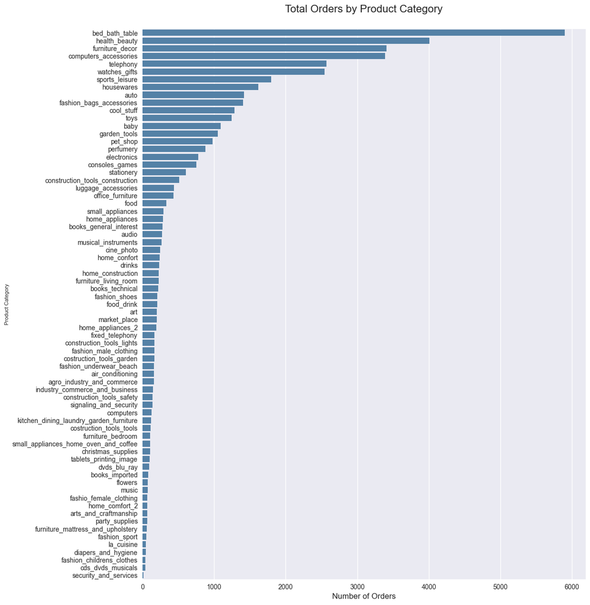

```python
# Configure visual parameters for executive reporting
plt.figure(figsize=(12,15))

# Determine categorical ranking by descending transaction frequency
category_order = df_orders_cleaned['top_product_category'].value_counts().index

# Render categorical velocity distribution
sns.countplot(
    data = df_orders_cleaned,
    y = 'top_product_category',
    order = category_order,
    color='steelblue',
)

# Refine chart aesthetics for professional presentation
plt.title('Total Orders by Product Category', fontsize = 16, pad = 25)
plt.xlabel('Number of Orders', fontsize = 12)
plt.ylabel('Product Category', fontsize = 8)

plt.show()
```

#### Brief interpretation

Overall, this tells us that the store is known more for its top few products amongst its customer base.

### Box Plot: Order Value vs Number of Items

The relationship between physical order volume and gross financial value is evaluated using a distributional lens. By plotting order_total_value against the discrete num_items variable, the workflow identifies how capital allocation shifts as consumers increase their purchase quantity. This visualization is pivotal for detecting price outliers and understanding the variance in spending patterns across different basket sizes.

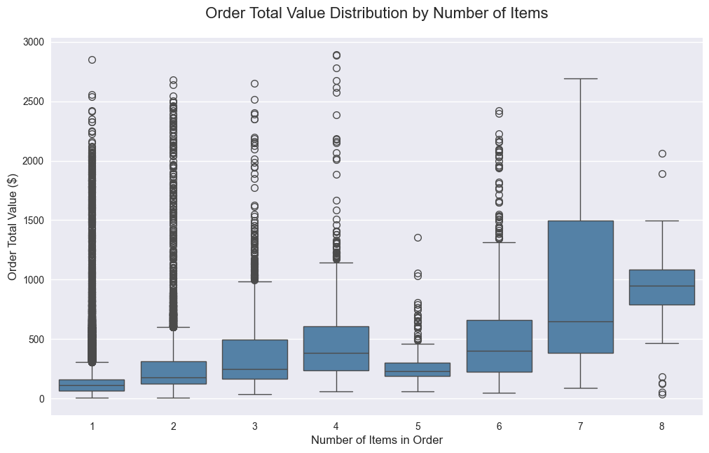

```python
# Configure canvas for distributional bivariate analysis
plt.figure(figsize=(12,7))

# Generate box plot to visualize value distribution and extreme outliers
sns.boxplot(
    data = df_orders_cleaned,
    x = 'num_items',
    y = 'order_total_value',
    color='steelblue'
)

# Enhance aesthetics for professional reporting
plt.title('Order Total Value Distribution by Number of Items', fontsize = 16, pad = 20)
plt.xlabel('Number of Items in Order', fontsize = 12)
plt.ylabel('Order Total Value ($)', fontsize = 12)

plt.show()
```

← Back to Project Report